# Arbeitspaket (AP) 2: Advanced Data Preparation & Exploratory Data Analysis (EDA)

### Persönliche Angaben (bitte ergänzen)

[output not shown]

## Bewertungskriterien

### **(max. erreichbare Punkte: 48)**

[output not shown]

## Python Libraries und Settings

```python
# Bibliotheken und Einstellungen für die Analyse
# - pandas (pd): Für Datenverarbeitung und -analyse
# - numpy (np): Für numerische Operationen
# - seaborn (sns): Für statistische Visualisierungen
# - sqlite3/sqlalchemy: Für Datenbankzugriff
# - re: Für reguläre Ausdrücke (Pattern Matching)

import os
import re
import random
import sqlite3
import pandas as pd
import numpy as np
import seaborn as sns
import matplotlib.pyplot as plt
import statsmodels.api as sm
from datetime import datetime, timedelta
from sqlalchemy import create_engine, text

# Seaborn Design-Einstellungen (kann angepasst werden)
sns.set_theme(color_codes=True)

# Warnungen ausblenden (bei Bedarf entfernen für Fehlerbehebung)
import warnings
warnings.filterwarnings("ignore")

# Aktuelles Arbeitsverzeichnis anzeigen
print(os.getcwd())
```

```
/workspaces/python_exploratory_data_analysis/old exam
```

## **Vorbereitung (Dieser Teil wird nicht bewertet!)**

#### **1.) Starten Sie eine GitHub Codespaces Instanz auf Basis Ihres Forks des folgenden GitHub Repositories:**

##### GitHub-Repository: https://github.com/mario-gellrich-zhaw/python_exploratory_data_analysis

## **Aufgaben (Dieser Teil wird bewertet!)**

**Hinweise zu den folgenden Aufgabenstellungen:**

- Beachten Sie auch die zu jeder Aufgabenstellung zugehörenden Details zu Aufgabenstellung.
- Lösen Sie jede Aufgabe mit Hilfe von Python Code. Integrieren Sie den Python Code in die Code-Zellen der jeweiligen Aufgabe.
- Stellen Sie die Lösung(en) jeder Aufgabe ganz oder in Teilen (z.B. erste 5 Zeilen) eines DataFrames im Jupyter Notebook dar.
- Stellen Sie sämtliche von Ihnen erstellte Graphiken im Jupyter Notebook dar.

#### **Aufgabe (1): Lesen Sie den Datensatz 'smartphone_data.csv' aus dem Order 'Data' ein, und speichern Sie diesen in einem pandas DataFrame.**

**Details zur Aufgabenstellung:**

- Zeigen Sie die Dimension des DataFrames (Zeilen und Spalten) im Jupyter Notebook an.
- Zeigen Sie die Datentypen sämtlicher Spalten des DataFrames im Jupyter Notebook an.
- Zeigen Sie die ersten Zeilen des DataFrames im Jupyter Notebook an.
- Tipp: Berücksichtigen Sie den Pfad der Ablage der Daten im Ordner Data ('./Data/smartphone_data.csv').

**(max. erreichbare Punkte: 4)**

```python
# Aufgabe 1: Daten einlesen und grundlegende Informationen anzeigen
# Parameter die angepasst werden können:
# - sep=';': Trennzeichen in der CSV-Datei
# - encoding='utf-8': Zeichenkodierung
# - head(): Anzahl der anzuzeigenden Zeilen (Standard: 5)

# Einlesen der Daten
df = pd.read_csv('./Data/smartphone_data.csv',
                   sep=';',
                   encoding='utf-8')

# Dimension des DataFrames anzeigen (Zeilen x Spalten)
print(f'Anzahl Zeilen: {df.shape[0]}; Anzahl Spalten: {df.shape[1]}', '\n')

# Datentypen der Spalten anzeigen
print('Datentypen:\n', df.dtypes, '\n')

# Erste 5 Zeilen anzeigen
df.head()
```

```
Anzahl Zeilen: 5000; Anzahl Spalten: 12

Datentypen:
 offer_id                   int64
dealer_plz                 int64
dealer_city               object
dealer_street_house_nr    object
make                      object
model                     object
price_raw                 object
camera_resolution_raw     object
battery_life_raw          object
storage_size_raw          object
screen_size_raw           object
description_raw           object
dtype: object
```

|  | offer_id | dealer_plz | dealer_city | dealer_street_house_nr | make | model | price_raw | camera_resolution_raw | battery_life_raw | storage_size_raw | screen_size_raw | description_raw |
| --- | --- | --- | --- | --- | --- | --- | --- | --- | --- | --- | --- | --- |
| 0 | 83197857 | 6394 | Volketswil | Blaserstrasse 19 | Apple | iPhone 13 | CHF 2518.- | 20 MP | 16 hrs | 256 GB | 6.1 IN | Langlebige Batterie mit Schnellladefunktion, d... |
| 1 | 36687537 | 9532 | Oberwil | Furrerstrasse 1 | Vivo | Vivo V21 | CHF 266.- | 12 MP | 16 hrs | 128 GB | 5.8 IN | Modernste Gesichtserkennungstechnologie für Si... |
| 2 | 66722344 | 2227 | Rüti | Maierstrasse 31 | Vivo | Vivo V21 | CHF 424.- | 12 MP | 20 hrs | 256 GB | 5.8 IN | Ultra-HD-Display für eine atemberaubende Bildq... |
| 3 | 56164955 | 5766 | Bülach | Sidlerstrasse 6 | Google | Pixel 6a | CHF 597.- | 12 MP | 25 hrs | 64 GB | 5.8 IN | Mit Stiftunterstützung für Kreativität und Prä... |
| 4 | 94374605 | 8304 | Belp | Steinerstrasse 8 | Google | Pixel 6 | CHF 1934.- | 20 MP | 23 hrs | 64 GB | 5.8 IN | Aufgeteilt in benutzerfreundliche Kategorien f... |

#### Falls Sie den Datensatz 'smartphone_data.csv' nicht einlesen konnten, verwenden Sie die SQLite DB 'smartphone_data.db' im Order 'Data'.

#### **Der folgende Python-Code liesst die Daten aus der SQLite DB in ein pandas DataFrame mit dem Namen 'df'.**

```
# Engine für Datenbankverbindung erstellen
engine = create_engine('sqlite:///./Data/smartphone_data.db')

# SQL Abfrage
df = pd.read_sql_query("""SELECT * FROM smartphone_data""",
                          con=engine)

# Schliessen der Datenbankverbindung
engine.dispose()

# Anzeigen des DataFrames (erste 5 Zeilen)
df.head()
```

#### **Aufgabe (2): Extrahieren Sie die numerischen Werte der folgenden Variablen, und speichern Sie diese in separaten Variablen im DataFrame ab.**

**Details zur Aufgabenstellung:**

- Extrahieren Sie die numerischen Werte der folgenden Variablen, und speichern Sie diese in separaten Variablen ab:
  - price_raw
  - camera_resolution_raw
  - battery_life_raw
  - storage_size_raw
  - screen_size_raw
- Benennen Sie die Spalten der neuen Variablen als (in Klammern ist der Datentyp angegeben):
  - price (int64)
  - camera_resolution (int64)
  - battery_life (int64)
  - storage_size (int64)
  - screen_size (float64)
- Stellen Sie ein Subset des DataFrames nur mit den neuen Spalten und den ersten 5 Zeilen im Jupyter Notebook dar.
- Tipp: Die folgenden regular expressions sind eine Hilfestellung zum Lösen der Aufgabe:

  ```
  "CHF\s*(\d+)\.-"
  "(\d+)\s*MP"
  "(\d+)\s*hrs"
  "(\d+)\s*GB"
  "(\d+\.\d+)\s*IN"
  ```

**(max. erreichbare Punkte: 8)**

```python
# Aufgabe 2: Extrahieren numerischer Werte aus Text mit regulären Ausdrücken
# Beispiel für 'price': Extrahiert Zahlen aus Format "CHF XX.-"
# Anpassbar:
# - Regex Pattern "CHF\s*(\d+)\.-" für anderes Preisformat
# - dtype="int64" für anderen Datentyp

# Extrahieren der Preise
price = []
for i in df['price_raw']:
    d1 = re.findall("CHF\s*(\d+)\.-", i)  # Sucht Muster "CHF XX.-"
    try:
        d2 = int(''.join(d1))  # Konvertiert zu Integer
    except:
        d2 = None  # Bei Fehlern: None setzen
    price.append(d2)

# Als neue Spalte im DataFrame speichern
df['price'] = pd.Series(price, dtype="int64")
```

```python
# Extrahieren der numerischen Werte aus 'camera_resolution_raw' und speichern in separaten Variablen
camera = []
for i in df['camera_resolution_raw']:
    d1 = re.findall("(\d+)\s*MP", i)
    try:
        d2 = int(''.join(d1))
    except:
        d2 = None
    camera.append(d2)

# Save as new variable in the pandas data frame
df['camera_resolution'] = pd.Series(camera, dtype="int64")
```

```python
# Extrahieren der numerischen Werte aus 'battery_life_raw' und speichern in separaten Variablen
battery = []
for i in df['battery_life_raw']:
    d1 = re.findall("(\d+)\s*hrs", i)
    try:
        d2 = int(''.join(d1))
    except:
        d2 = None
    battery.append(d2)

# Save as new variable in the pandas data frame
df['battery_life'] = pd.Series(battery, dtype="int64")
```

```python
# Extrahieren der numerischen Werte aus 'storage_size_raw' und speichern in separaten Variablen
storage = []
for i in df['storage_size_raw']:
    d1 = re.findall("(\d+)\s*GB", i)
    try:
        d2 = int(''.join(d1))
    except:
        d2 = None
    storage.append(d2)

# Save as new variable in the pandas data frame
df['storage_size'] = pd.Series(storage, dtype="int64")
```

```python
# Extrahieren der numerischen Werte aus 'screen_size_raw' und speichern in separaten Variablen (Tipp: float statt int)
screen = []
for i in df['screen_size_raw']:
    d1 = re.findall("(\d+\.\d+)\s*IN", i)
    try:
        d2 = float(''.join(d1)) # use 'float' instead of 'int'
    except:
        d2 = None
    screen.append(d2)

# Save as new variable in the pandas data frame
df['screen_size'] = pd.Series(screen, dtype="float64")
```

```python
# Anzeigen Subset des DataFrames nur mit den neuen Variablen und den ersten 5 Zeilen
df[['price', 'camera_resolution', 'battery_life', 'storage_size', 'screen_size']].head()
```

|  | price | camera_resolution | battery_life | storage_size | screen_size |
| --- | --- | --- | --- | --- | --- |
| 0 | 2518 | 20 | 16 | 256 | 6.1 |
| 1 | 266 | 12 | 16 | 128 | 5.8 |
| 2 | 424 | 12 | 20 | 256 | 5.8 |
| 3 | 597 | 12 | 25 | 64 | 5.8 |
| 4 | 1934 | 20 | 23 | 64 | 5.8 |

#### **Aufgabe (3): Erstellen Sie statistische Kennzahlen zu den numerischen Variablen im DataFrame.**

**Details zur Aufgabenstellung:**

- Berechnen Sie die statistische Kennzahlen für die Variablen 'price', 'camera_resolution', 'battery_life', 'storage_size', 'screen_size'.
- Die statistische Kennzahlen, welche berechnet werden sollen sind (engl. Bezeichnungen):
  - Count
  - Mean
  - Standard Deviation (std)
  - Minimum
  - 25th Percentile (= 1st Quartile)
  - 50th Percentile (= Median)
  - 75th Percentile (= 3rd Quartile)
  - Maximum
  - Skewness
- Stellen Sie die berechneten statistische Kennzahlen im Jupyter Notebook dar (es können auch verschiedene Ergebnistabellen angezeigt werden).
- Tipp: Nicht alle Python - Methoden verwenden automatisch nur die numerischen Variablen. In diesen Fällen muss ein Subset der numerischen Variablen erstellt werden.

**(max. erreichbare Punkte: 4)**

```python
# Einlesen der aufbereiteten Daten (damit alle auf dem gleichen Stand sind)
engine = create_engine('sqlite:///./Data/smartphone_data_prepared.db')
df = pd.read_sql_query("""SELECT * FROM smartphone_data_prepared""", con=engine)
engine.dispose()

# Berechnung der statistischen Kennzahlen der numerischen Spalten in 'df'
print('Summary Statistic:\n', df.describe().round(2))
# count: Anzahl nicht-null Werte
# mean: Durchschnitt
# std: Standardabweichung
# min/max: Minimum/Maximum
# 25%/50%/75%: Quartile

# Separate Berechnung der Skewness der numerischen Spalten
cols = ['price', 'camera_resolution', 'battery_life', 'storage_size', 'screen_size']
skewness = df[cols].skew().round(4)
print('\nSkewness:\n', skewness)
# Schiefe (skewness) separat berechnen:
# > 0: rechtsschiefe Verteilung
# < 0: linksschiefe Verteilung
# ≈ 0: symmetrische Verteilung
```

```
Summary Statistic:
           offer_id  dealer_plz     price  camera_resolution  battery_life  \
count      5000.00     5000.00   5000.00            5000.00       5000.00
mean   55197271.47     5559.51   1391.03              22.99         22.56
std    25815003.01     2599.28   1359.78              21.90          5.31
min    10008043.00     1000.00     18.00              12.00         15.00
25%    33059199.00     3300.50    546.00              12.00         18.00
50%    54908941.50     5557.50    975.50              16.00         22.00
75%    77253679.00     7784.50   1763.00              20.00         26.00
max    99985448.00     9999.00  17091.00             108.00         35.00

       storage_size  screen_size
count       5000.00      5000.00
mean         211.00         6.15
std          165.66         0.36
min           64.00         5.80
25%           64.00         5.80
50%          128.00         6.10
75%          256.00         6.50
max          512.00         6.90

Skewness:
 price                3.0052
camera_resolution    2.7580
battery_life         0.4858
storage_size         0.9657
screen_size          0.6616
dtype: float64
```

#### **Aufgabe (4): Erstellen Sie eine Pivot-Tabelle mit den Mittwelwerten der numerischen Variablen pro Hersteller.**

**Details zur Aufgabenstellung:**

- Die Angabe zum Hersteller finden Sie in der Variable 'make'.
- Verwenden Sie die für die Mittelwertsberechnung die Variablen 'price', 'camera_resolution', 'battery_life', 'storage_size', 'screen_size'.
- Stellen Sie die Pivot-Tabelle im Jupyter Notebook dar.

**(max. erreichbare Punkte: 4)**

```python
# Aufgabe 4: Pivot-Tabelle für Mittelwerte pro Hersteller
# Anpassbar:
# - index='make': Gruppierungsvariable
# - values=[...]: Zu berechnende Spalten
# - aggfunc='mean': Aggregationsfunktion (z.B. 'mean', 'median', 'sum')
# - round(2): Dezimalstellen

# Pivot-Tabelle erstellen
pivot_table = df.pivot_table(index='make',
                             values=['price',
                                     'camera_resolution',
                                     'battery_life',
                                     'storage_size',
                                     'screen_size'],
                             aggfunc='mean').round(2)

# Pivot-Tabelle anzeigen
pivot_table
```

| make | battery_life | camera_resolution | price | screen_size | storage_size |
| --- | --- | --- | --- | --- | --- |
| Apple | 22.61 | 23.23 | 2120.24 | 6.13 | 208.90 |
| Google | 22.48 | 22.32 | 1583.31 | 6.16 | 214.17 |
| Samsung | 22.62 | 22.37 | 1343.23 | 6.16 | 209.06 |
| Vivo | 22.65 | 23.80 | 842.75 | 6.15 | 214.25 |
| Xiaomi | 22.41 | 23.26 | 1058.12 | 6.13 | 208.87 |

#### **Aufgabe (5): Erstellen Sie ein Histogramm der Variable 'price'.**

**Details zur Aufgabenstellung:**

- Setzen Sie die Anzahl der Klassen (engl.: bins) auf den Wert 25.
- Beschriften Sie die Achsen des Histogramms, und fügen Sie einen Titel hinzu.
- Fügen Sie der Graphik ein Gitternetz (engl.: grid) hinzu.
- Zeigen Sie das Histogramm im Jupyter Notebook an.

**(max. erreichbare Punkte: 8)**

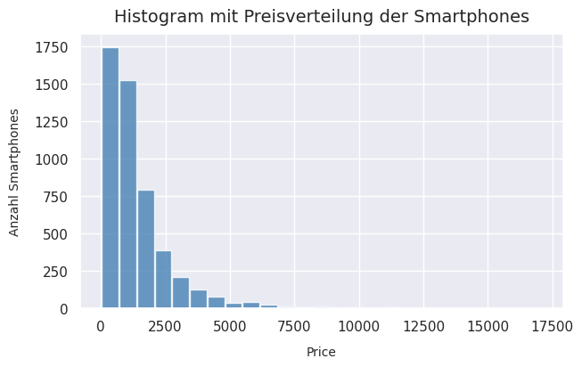

```python
# Aufgabe 5: Histogramm der Preisverteilung
# Anpassbare Parameter:
# - figsize=(7,4): Größe der Grafik
# - bins=25: Anzahl der Balken
# - color='steelblue': Farbe der Balken
# - alpha=0.80: Transparenz (0-1)
# - fontsize: Schriftgrößen

# Histogramm erstellen
fig = plt.figure(figsize=(7,4))
n, bins, patches = plt.hist(x=df['price'],
                            bins=25,
                            color='steelblue',
                            alpha=0.80,
                            rwidth=0.95)

# Beschriftungen
plt.xlabel('Price', fontsize=10, labelpad=10)
plt.ylabel('Anzahl Smartphones', fontsize=10, labelpad=10)
plt.title('Histogram mit Preisverteilung der Smartphones', fontsize=14, pad=10)

# Gitternetz hinzufügen
plt.grid(True)

plt.show()
```

#### **Aufgabe (6): Erstellen Sie einen gruppierten Boxplot mit den Preisen pro Hersteller.**

**Details zur Aufgabenstellung:**

- Verwenden Sie die Python Library seaborn für die Erstellung des gruppieren Boxplots.
- Die Angabe zum Hersteller (=Gruppierungsvariable) finden Sie in der Variable 'make'.
- Beschriften Sie die Achsen und geben Sie der Graphik einen Titel.
- Stellen Sie den gruppierten Boxplot im Jupyter Notebook dar.
- Tipp: Für die Erstellung des gruppierten Boxplots können Sie Vorlagen aus der seaborn - Hilfe verwenden (vgl. Abschnitt: 'Group by a categorical variable ...'):  
  https://seaborn.pydata.org/generated/seaborn.boxplot.html

**(max. erreichbare Punkte: 8)**

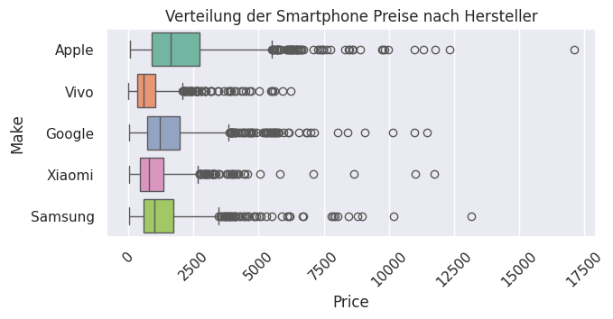

```python
# Aufgabe 6: Gruppierter Boxplot für Preise pro Hersteller
# Anpassbare Parameter:
# - figsize=(7,3): Größe der Grafik
# - x='price': Variable für x-Achse
# - y='make': Gruppierungsvariable
# - orient='h': Ausrichtung ('h' horizontal, 'v' vertikal)
# - palette='Set2': Farbpalette

# Boxplot erstellen
plt.figure(figsize=(7, 3))
sns.boxplot(x='price',
            y='make',
            data=df,
            orient='h',
            palette='Set2')

# Beschriftungen
plt.title('Verteilung der Smartphone Preise nach Hersteller', fontsize=12)
plt.xlabel('Price')
plt.ylabel('Make')
plt.xticks(rotation=45)
plt.show()
```

#### **Aufgabe (7): Erstellen Sie ein Barchart mit der Anzahl Smartphones pro Hersteller.**

**Details zur Aufgabenstellung:**

- Ergänzen Sie den Python Code unten dort wo notwendig.
- Die Angabe zum Hersteller finden Sie in der Variable 'make'.
- Im Barchart müssen die Hersteller auf der vertikalen und die Anzahl Smartphones auf der horizontalen Achse abgebildet sein.
- Im Barchart müssen die Anzahl Smartphones pro Hersteller der Grösse nach absteigend sortiert sein.
- Beschriften Sie die Achsen des Barcharts und geben Sie dem Barchart einen Titel.

**(max. erreichbare Punkte: 8)**

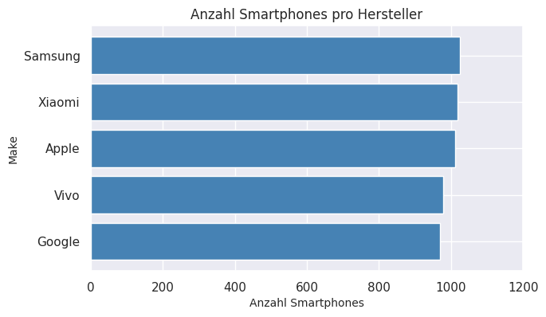

```python
# Aufgabe 7: Barchart für Anzahl Smartphones pro Hersteller
# Anpassbare Parameter:
# - figsize=(7,4): Größe der Grafik
# - color='steelblue': Farbe der Balken
# - ascending=True: Sortierreihenfolge
# - set_xlim(0, 1200): Grenzen der x-Achse

# Daten gruppieren und sortieren
df_bar = df['make'].value_counts().sort_values(ascending=True)

# Werte für Barchart vorbereiten
napart = list(df_bar.values)
index = list(df_bar.index.values)
y_pos = np.arange(len(index))

# Barchart erstellen
fig, ax = plt.subplots(figsize=(7,4))
ax.barh(y_pos, napart, align='center', color='steelblue')
ax.set_yticks(y_pos, index)
ax.set_xlabel('Anzahl Smartphones', fontsize=10)
ax.set_ylabel('Make', fontsize=10)
ax.set_xlim(0, 1200)
ax.set_title('Anzahl Smartphones pro Hersteller', fontsize=12)

plt.show()
```

#### **Aufgabe (8): Erstellen Sie eine Correlation-Heatmap auf der Basis der numerischen Variablen.**

**Details zur Aufgabenstellung:**

- Verwenden Sie die Variablen 'price', 'camera_resolution', 'battery_life', 'storage_size', 'screen_size'.
- Berechnen Sie auf zwei Nachkommastellen gerundete Korrelationskoeffizienten als Basis für die Correlation-Matrix und -Heatmap.
- Stellen Sie die Correlation-Matrix im Jupyter Notebook dar.
- Stellen Sie die Correlation-Heatmap im Jupyter Notebook dar.

**(max. erreichbare Punkte: 8)**

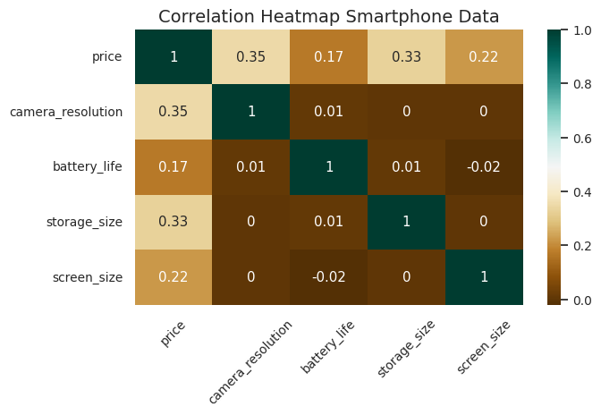

```python
# Aufgabe 8: Korrelations-Heatmap erstellen
# Anpassbare Parameter:
# - font_scale=0.9: Schriftgröße
# - figsize=(7,4): Größe der Grafik
# - cmap="BrBG": Farbschema der Heatmap
# - round(2): Dezimalstellen der Korrelationen
# - rotation=45: Rotation der x-Achsen-Beschriftungen

# Schriftgröße einstellen
sns.set_theme(font_scale=0.9)

# Korrelationsmatrix berechnen
corr = df[['price',
           'camera_resolution',
           'battery_life',
           'storage_size',
           'screen_size']].corr().round(2)

# Heatmap erstellen
plt.figure(figsize=(7,4))
sns.heatmap(corr,
            cmap="BrBG",
            annot=True)
plt.title('Correlation Heatmap Smartphone Data', fontsize=14)
plt.xticks(rotation=45)

plt.show()
```

### Jupyter notebook --footer info-- (please always provide this at the end of each notebook)

```python
import os
import platform
import socket
from platform import python_version
from datetime import datetime

print('-----------------------------------')
print(os.name.upper())
print(platform.system(), '|', platform.release())
print('Datetime:', datetime.now().strftime("%Y-%m-%d %H:%M:%S"))
print('Python Version:', python_version())
print('IP Address:', socket.gethostbyname(socket.gethostname()))
print('-----------------------------------')
```

```
-----------------------------------
POSIX
Linux | 6.8.0-1030-azure
Datetime: 2025-11-09 21:28:50
Python Version: 3.13.5
IP Address: 127.0.0.1
-----------------------------------
```